# Bank Marketing Data - A Decision Tree Approach

2024-05-03

## Context

As part of Reproducible Research course which is Mandatory course for 2nd year students of Data Science and Business Analytics, we are reproducing already existing project.

Link to the project: https://www.kaggle.com/code/shirantha/bank-marketing-data-a-decision-tree-approach

The aim of this project is to: 1. Verify reproductibility of the code. 2. Transform code from original code written in python to R. 3. Ensure that project written in R is reproductible. Ideally code should not require any user to adjust code to own environment. 4. Enhance referenced project.

## Dataset Description

As kaggle project was created as part of challenge, it was downloaded directly from kaggle and then has been loaded from local path. We decided to go to original destination of dataaset and we download dataset straight from UCI Machine Learning Repository. To do that we used a combination of remote and utils package. Original dataset had already renamed ‘deposit’ column to ‘y’ as it is dependent variable. We decided to rename it to ‘deposit’ for consistency with cited code. Please note that dataset used in kaggle used limited dataset to 11k observations, we use full dataset which consists of 45k observations.

Below is official description of dataset: “Citation Request: This dataset is public available for research. The details are described in [Moro et al., 2011]. Please include this citation if you plan to use this database:

[Moro et al., 2011] S. Moro, R. Laureano and P. Cortez. Using Data Mining for Bank Direct Marketing: An Application of the CRISP-DM Methodology. In P. Novais et al. (Eds.), Proceedings of the European Simulation and Modelling Conference - ESM’2011, pp. 117-121, Guimarães, Portugal, October, 2011. EUROSIS.

Available at: [pdf] http://hdl.handle.net/1822/14838 [bib] http://www3.dsi.uminho.pt/pcortez/bib/2011-esm-1.txt

1. Title: Bank Marketing
2. Sources Created by: Paulo Cortez (Univ. Minho) and Sérgio Moro (ISCTE-IUL) @ 2012
3. Past Usage:

The full dataset was described and analyzed in:

S. Moro, R. Laureano and P. Cortez. Using Data Mining for Bank Direct Marketing: An Application of the CRISP-DM Methodology. In P. Novais et al. (Eds.), Proceedings of the European Simulation and Modelling Conference - ESM’2011, pp. 117-121, Guimarães, Portugal, October, 2011. EUROSIS.

4. Relevant Information:

   The data is related with direct marketing campaigns of a Portuguese banking institution. The marketing campaigns were based on phone calls. Often, more than one contact to the same client was required, in order to access if the product (bank term deposit) would be (or not) subscribed.

   There are two datasets:
   1. bank-full.csv with all examples, ordered by date (from May 2008 to November 2010).
   2. bank.csv with 10% of the examples (4521), randomly selected from bank-full.csv. The smallest dataset is provided to test more computationally demanding machine learning algorithms (e.g. SVM).

   The classification goal is to predict if the client will subscribe a term deposit (variable y).
5. Number of Instances: 45211 for bank-full.csv (4521 for bank.csv)
6. Number of Attributes: 16 + output attribute.
7. Attribute information:

   For more information, read [Moro et al., 2011].

   Input variables: # bank client data: 1 - age (numeric) 2 - job : type of job (categorical: “admin.”,“unknown”,“unemployed”,“management”,“housemaid”,“entrepreneur”,“student”, “blue-collar”,“self-employed”,“retired”,“technician”,“services”) 3 - marital : marital status (categorical: “married”,“divorced”,“single”; note: “divorced” means divorced or widowed) 4 - education (categorical: “unknown”,“secondary”,“primary”,“tertiary”) 5 - default: has credit in default? (binary: “yes”,“no”) 6 - balance: average yearly balance, in euros (numeric) 7 - housing: has housing loan? (binary: “yes”,“no”) 8 - loan: has personal loan? (binary: “yes”,“no”) # related with the last contact of the current campaign: 9 - contact: contact communication type (categorical: “unknown”,“telephone”,“cellular”) 10 - day: last contact day of the month (numeric) 11 - month: last contact month of year (categorical: “jan”, “feb”, “mar”, …, “nov”, “dec”) 12 - duration: last contact duration, in seconds (numeric) # other attributes: 13 - campaign: number of contacts performed during this campaign and for this client (numeric, includes last contact) 14 - pdays: number of days that passed by after the client was last contacted from a previous campaign (numeric, -1 means client was not previously contacted) 15 - previous: number of contacts performed before this campaign and for this client (numeric) 16 - poutcome: outcome of the previous marketing campaign (categorical: “unknown”,“other”,“failure”,“success”)

Output variable (desired target): 17 - y - has the client subscribed a term deposit? (binary: “yes”,“no”)

8. Missing Attribute Values: None ” ## Dataset Preparation

```r
zip_url <- "https://archive.ics.uci.edu/static/public/222/bank+marketing.zip"
zip_file <- "bank.zip"
download.file(zip_url, zip_file)
unzip(zip_file, exdir = "bank_dataset")

csv_file_path <- "bank_dataset/bank-full.csv"
bank <- read.csv(csv_file_path, sep = ";")



bank <- bank %>% rename(deposit = y)

variables <- data.frame(
  name = colnames(bank),
  type = sapply(bank, class)
)
print(variables)
```

|  | name | type |
| --- | --- | --- |
| age | age | integer |
| job | job | character |
| marital | marital | character |
| education | education | character |
| default | default | character |
| balance | balance | integer |
| housing | housing | character |
| loan | loan | character |
| contact | contact | character |
| day | day | integer |

[output cut: 7 more lines]

```r
NA
```

Once loaded, we started first with listing down the summary of downloaded dataset.

```r
summary(bank)
```

```
      age            job              marital           education
 Min.   :18.00   Length:45211       Length:45211       Length:45211
 1st Qu.:33.00   Class :character   Class :character   Class :character
 Median :39.00   Mode  :character   Mode  :character   Mode  :character
 Mean   :40.94
 3rd Qu.:48.00
 Max.   :95.00
   default             balance         housing              loan
 Length:45211       Min.   : -8019   Length:45211       Length:45211
 Class :character   1st Qu.:    72   Class :character   Class :character
 Mode  :character   Median :   448   Mode  :character   Mode  :character
                    Mean   :  1362
                    3rd Qu.:  1428
                    Max.   :102127
   contact               day           month              duration
 Length:45211       Min.   : 1.00   Length:45211       Min.   :   0.0
 Class :character   1st Qu.: 8.00   Class :character   1st Qu.: 103.0
 Mode  :character   Median :16.00   Mode  :character   Median : 180.0
                    Mean   :15.81                      Mean   : 258.2
                    3rd Qu.:21.00                      3rd Qu.: 319.0
                    Max.   :31.00                      Max.   :4918.0
    campaign          pdays          previous          poutcome
 Min.   : 1.000   Min.   : -1.0   Min.   :  0.0000   Length:45211
 1st Qu.: 1.000   1st Qu.: -1.0   1st Qu.:  0.0000   Class :character
 Median : 2.000   Median : -1.0   Median :  0.0000   Mode  :character
 Mean   : 2.764   Mean   : 40.2   Mean   :  0.5803
 3rd Qu.: 3.000   3rd Qu.: -1.0   3rd Qu.:  0.0000
 Max.   :63.000   Max.   :871.0   Max.   :275.0000
   deposit
 Length:45211
 Class :character
 Mode  :character
```

First step to prepare dataset for any machine learning modeling is to determine the characteristics of dataset. First step is to verify whether dataset contains any missing values. This is done by visualizing summary of missing values per each column.

```r
# Brief verification of dataset to determine whether there are any missing values
bank %>% summarize(across(everything(), ~sum(is.na(.))))
```

| age | job | marital | education | default | balance | housing | loan | contact | day | month | duration | campaign | pdays | previous | poutcome | deposit |
| --- | --- | --- | --- | --- | --- | --- | --- | --- | --- | --- | --- | --- | --- | --- | --- | --- |
| 0 | 0 | 0 | 0 | 0 | 0 | 0 | 0 | 0 | 0 | 0 | 0 | 0 | 0 | 0 | 0 | 0 |

As it can be seen above, dataset does not contain any missing values, therefore there is no requirement to perform any engineering.

```r
summary(bank)
```

```
      age            job              marital           education
 Min.   :18.00   Length:45211       Length:45211       Length:45211
 1st Qu.:33.00   Class :character   Class :character   Class :character
 Median :39.00   Mode  :character   Mode  :character   Mode  :character
 Mean   :40.94
 3rd Qu.:48.00
 Max.   :95.00
   default             balance         housing              loan
 Length:45211       Min.   : -8019   Length:45211       Length:45211
 Class :character   1st Qu.:    72   Class :character   Class :character
 Mode  :character   Median :   448   Mode  :character   Mode  :character
                    Mean   :  1362
                    3rd Qu.:  1428
                    Max.   :102127
   contact               day           month              duration
 Length:45211       Min.   : 1.00   Length:45211       Min.   :   0.0
 Class :character   1st Qu.: 8.00   Class :character   1st Qu.: 103.0
 Mode  :character   Median :16.00   Mode  :character   Median : 180.0
                    Mean   :15.81                      Mean   : 258.2
                    3rd Qu.:21.00                      3rd Qu.: 319.0
                    Max.   :31.00                      Max.   :4918.0
    campaign          pdays          previous          poutcome
 Min.   : 1.000   Min.   : -1.0   Min.   :  0.0000   Length:45211
 1st Qu.: 1.000   1st Qu.: -1.0   1st Qu.:  0.0000   Class :character
 Median : 2.000   Median : -1.0   Median :  0.0000   Mode  :character
 Mean   : 2.764   Mean   : 40.2   Mean   :  0.5803
 3rd Qu.: 3.000   3rd Qu.: -1.0   3rd Qu.:  0.0000
 Max.   :63.000   Max.   :871.0   Max.   :275.0000
   deposit
 Length:45211
 Class :character
 Mode  :character
```

## Explatory Data Analysis

In Explatory Data Analysis chapter, aim is to identify dataset characteristics. This is done by plotting graphs.

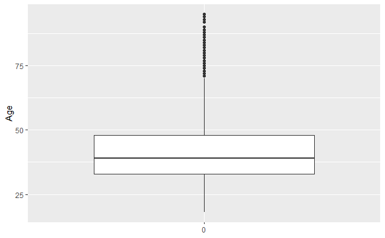

```r
g_age <- ggplot(bank, aes(x = factor(0), y = age)) +
  geom_boxplot() +
  labs(x = NULL, y = "Age") +
  theme(axis.title.x = element_blank())
g_age
```

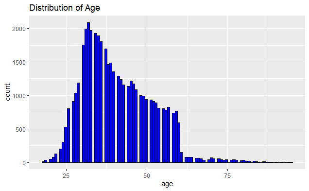

```r
g_age_dist <- ggplot(bank, aes(x = age)) +
  geom_histogram(bins = 100, fill = "blue", color = "black") +
  ggtitle("Distribution of Age")
g_age_dist
```

```r
bank_above_70 <- bank %>%
  filter(age > 70)

print(bank_above_70)
```

| age | job | marital | education | default | balance | housing | loan | contact | day | month | duration | campaign | pdays | previous | poutcome | deposit |
| --- | --- | --- | --- | --- | --- | --- | --- | --- | --- | --- | --- | --- | --- | --- | --- | --- |
| 83 | retired | married | primary | no | 425 | no | no | telephone | 2 | feb | 912 | 1 | -1 | 0 | unknown | no |
| 75 | retired | divorced | primary | no | 46 | no | no | cellular | 2 | feb | 294 | 1 | -1 | 0 | unknown | no |
| 75 | retired | married | primary | no | 3324 | no | no | cellular | 2 | feb | 149 | 1 | -1 | 0 | unknown | no |
| 83 | retired | married | tertiary | no | 6236 | no | no | cellular | 2 | feb | 283 | 2 | -1 | 0 | unknown | no |
| 75 | retired | divorced | primary | no | 3881 | yes | no | cellular | 4 | feb | 136 | 3 | -1 | 0 | unknown | yes |
| 72 | retired | married | primary | no | 9160 | no | no | cellular | 5 | feb | 229 | 1 | -1 | 0 | unknown | no |
| 71 | retired | married | tertiary | no | 2651 | no | no | cellular | 5 | feb | 531 | 2 | -1 | 0 | unknown | no |
| 76 | retired | married | primary | no | 2590 | no | no | telephone | 9 | feb | 68 | 12 | -1 | 0 | unknown | no |
| 83 | retired | single | primary | no | 3349 | no | no | telephone | 12 | feb | 89 | 1 | -1 | 0 | unknown | no |
| 71 | retired | married | unknown | no | 362 | no | no | telephone | 12 | feb | 139 | 2 | -1 | 0 | unknown | no |

[output cut: 477 more lines]

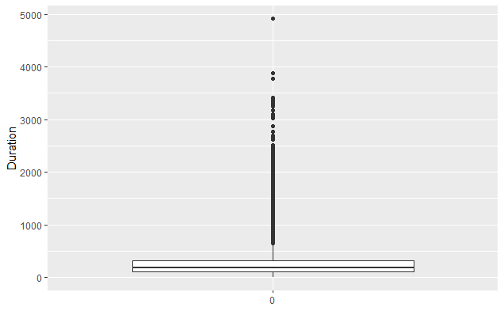

```r
g_duration <- ggplot(bank, aes(x = factor(0), y = duration)) +
  geom_boxplot() +
  labs(x = NULL, y = "Duration") +
  theme(axis.title.x = element_blank())
g_duration
```

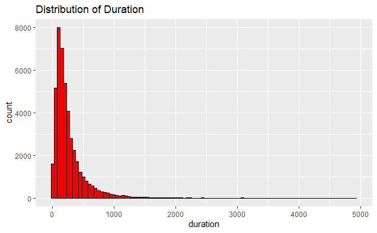

```r
g_duration_dist <- ggplot(bank, aes(x = duration)) +
  geom_histogram(bins = 100, fill = "red", color = "black") +
  ggtitle("Distribution of Duration")
g_duration_dist
```

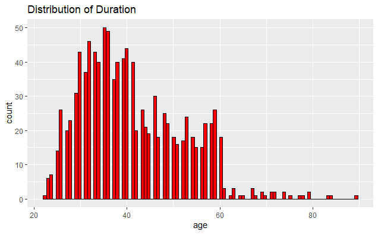

```r
g_duration_dist <- ggplot(bank%>%filter(duration>1000), aes(x = age)) +
  geom_histogram(bins = 100, fill = "red", color = "black") +
  ggtitle("Distribution of Duration")
g_duration_dist
```

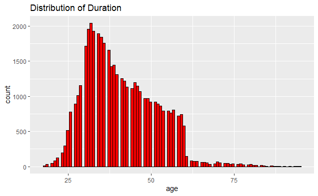

```r
g_duration_dist <- ggplot(bank%>%filter(duration<1000), aes(x = age)) +
  geom_histogram(bins = 100, fill = "red", color = "black") +
  ggtitle("Distribution of Duration")
g_duration_dist
```